# Power calculations

2023-01-23

```r
## In case you are not using RStudio but need the params
if( !exists("params") ){
    params <- rmarkdown::yaml_front_matter(here::here("analysis/scripts", "2233-power-calculations.Rmd"))$params
}
```

# Power calculations

**Project number**: 2233

**Project name**: USWDS Digital Dashboard

**Author**: Ben Jaques-Leslie

**Data**: wds.rdata’

## Load data

### Data from wds.rdata

```r
load(file.path(params$data_folder,params$data))
```

Review data.

```r
d %>% skim()
```

Data summary

| Name | Piped data |
| --- | --- |
| Number of rows | 102154 |
| Number of columns | 6 |
| _______________________ |  |
| Column type frequency: |  |
| character | 1 |
| Date | 3 |
| factor | 1 |
| numeric | 1 |
| ________________________ |  |
| Group variables | None |

**Variable type: character**

| skim_variable | n_missing | complete_rate | min | max | empty | n_unique | whitespace |
| --- | --- | --- | --- | --- | --- | --- | --- |
| website | 0 | 1 | 6 | 37 | 0 | 1131 | 0 |

**Variable type: Date**

| skim_variable | n_missing | complete_rate | min | max | median | n_unique |
| --- | --- | --- | --- | --- | --- | --- |
| date | 0 | 1 | 2017-12-28 | 2022-03-16 | 2019-10-28 | 133 |
| date_month | 0 | 1 | 2017-12-01 | 2022-03-01 | 2019-10-01 | 48 |
| date_week | 0 | 1 | 2017-12-24 | 2022-03-13 | 2019-10-27 | 91 |

**Variable type: factor**

| skim_variable | n_missing | complete_rate | ordered | n_unique | top_counts |
| --- | --- | --- | --- | --- | --- |
| name | 0 | 1 | FALSE | 4 | htm: 32125, col: 32116, mis: 32111, usw: 5802 |

**Variable type: numeric**

| skim_variable | n_missing | complete_rate | mean | sd | p0 | p25 | p50 | p75 | p100 | hist |
| --- | --- | --- | --- | --- | --- | --- | --- | --- | --- | --- |
| value | 33873 | 0.67 | 9.91 | 23.65 | 0 | 0 | 2 | 7 | 761 | ▇▁▁▁▁ |

Review the data by outcome and treatment.

```r
d %>% group_by(name) %>%  skim()
```

Data summary

| Name | Piped data |
| --- | --- |
| Number of rows | 102154 |
| Number of columns | 6 |
| _______________________ |  |
| Column type frequency: |  |
| character | 1 |
| Date | 3 |
| numeric | 1 |
| ________________________ |  |
| Group variables | name |

**Variable type: character**

| skim_variable | name | n_missing | complete_rate | min | max | empty | n_unique | whitespace |
| --- | --- | --- | --- | --- | --- | --- | --- | --- |
| website | color_contrast_issues | 0 | 1 | 6 | 37 | 0 | 1112 | 0 |
| website | html_aattribute_issues | 0 | 1 | 6 | 37 | 0 | 1112 | 0 |
| website | missing_image_issues | 0 | 1 | 6 | 37 | 0 | 1112 | 0 |
| website | uswds_score | 0 | 1 | 6 | 33 | 0 | 99 | 0 |

**Variable type: Date**

| skim_variable | name | n_missing | complete_rate | min | max | median | n_unique |
| --- | --- | --- | --- | --- | --- | --- | --- |
| date | color_contrast_issues | 0 | 1 | 2017-12-28 | 2022-03-06 | 2019-10-07 | 97 |
| date | html_aattribute_issues | 0 | 1 | 2017-12-28 | 2022-03-06 | 2019-10-07 | 97 |
| date | missing_image_issues | 0 | 1 | 2017-12-28 | 2022-03-06 | 2019-10-07 | 97 |
| date | uswds_score | 0 | 1 | 2020-06-18 | 2022-03-16 | 2021-05-19 | 81 |
| date_month | color_contrast_issues | 0 | 1 | 2017-12-01 | 2022-03-01 | 2019-10-01 | 47 |
| date_month | html_aattribute_issues | 0 | 1 | 2017-12-01 | 2022-03-01 | 2019-10-01 | 47 |
| date_month | missing_image_issues | 0 | 1 | 2017-12-01 | 2022-03-01 | 2019-10-01 | 47 |
| date_month | uswds_score | 0 | 1 | 2020-06-01 | 2022-03-01 | 2021-05-01 | 22 |
| date_week | color_contrast_issues | 0 | 1 | 2017-12-24 | 2022-03-06 | 2019-10-06 | 81 |
| date_week | html_aattribute_issues | 0 | 1 | 2017-12-24 | 2022-03-06 | 2019-10-06 | 81 |
| date_week | missing_image_issues | 0 | 1 | 2017-12-24 | 2022-03-06 | 2019-10-06 | 81 |
| date_week | uswds_score | 0 | 1 | 2020-06-14 | 2022-03-13 | 2021-05-16 | 50 |

**Variable type: numeric**

| skim_variable | name | n_missing | complete_rate | mean | sd | p0 | p25 | p50 | p75 | p100 | hist |
| --- | --- | --- | --- | --- | --- | --- | --- | --- | --- | --- | --- |
| value | color_contrast_issues | 11022 | 0.66 | 8.69 | 21.24 | 0 | 1 | 3 | 10 | 761 | ▇▁▁▁▁ |
| value | html_aattribute_issues | 6168 | 0.81 | 6.28 | 12.78 | 0 | 1 | 2 | 6 | 307 | ▇▁▁▁▁ |
| value | missing_image_issues | 16661 | 0.48 | 3.49 | 6.49 | 0 | 0 | 1 | 4 | 69 | ▇▁▁▁▁ |
| value | uswds_score | 22 | 1.00 | 47.89 | 49.96 | 0 | 0 | 0 | 100 | 100 | ▇▁▁▁▇ |

## Understanding the outcome distribution

### Overall distribution of issues.

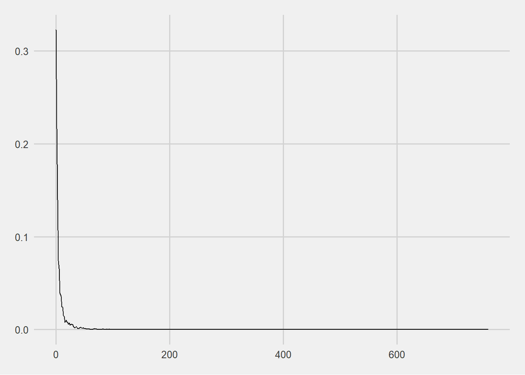

```r
d %>%
  filter(name != "uswds_score") %>%
  ggplot(aes(x = value)) +
  geom_density() +
  theme_fivethirtyeight() #+
```

```r
  # scale_fill_oes()
```

### Distribution by issue count and WDS score.

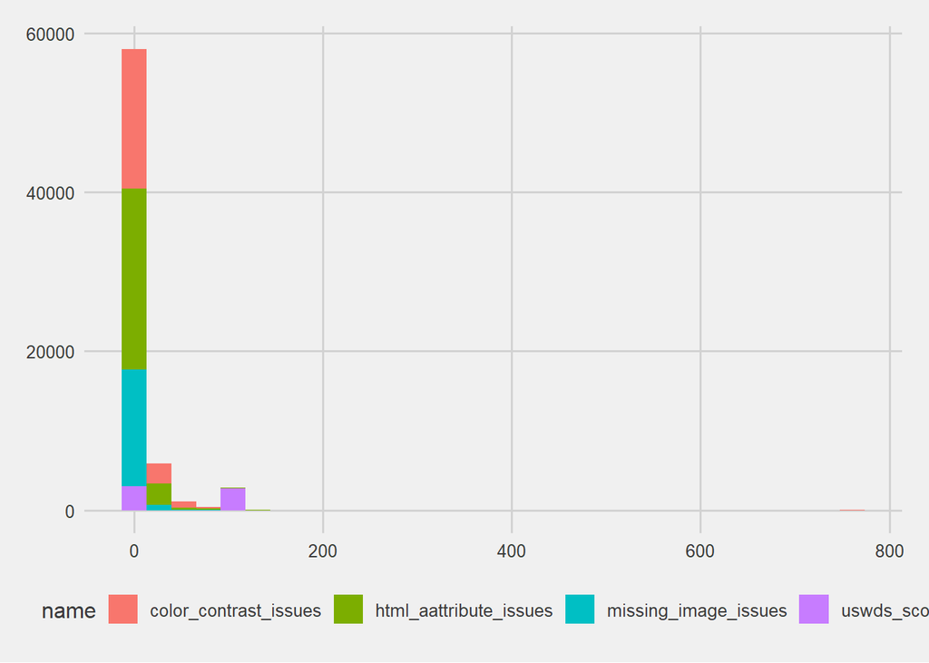

```r
d %>%
  ggplot(aes(x = value, fill = name)) +
  geom_histogram() +
  # scale_fill_oes(palette = "full colors") +
  theme_fivethirtyeight()
```

When we treat the null values as zero, we have greater skew.

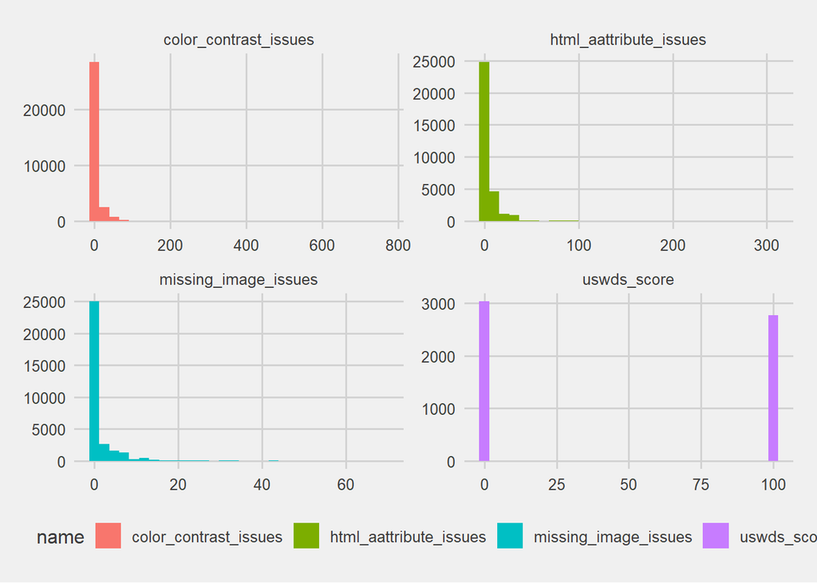

```r
d %>%
  mutate(value = replace_na(value, 0)) %>%
  ggplot(aes(x = value, fill = name)) +
  geom_histogram() +
  # scale_fill_oes(palette = "full colors") +
  theme_fivethirtyeight() +
  facet_wrap('name', scales = "free")
```

## Power analysis

### Assumptions

Several assumptions are based on the means and sample size of the USWDS data.

```r
prep_01 <-
  d %>%
  group_by(name) %>%
  summarise(mean = mean(value, na.rm = TRUE),
            websites = n_distinct(website)) %>%
  ungroup()

prep_01
```

```
## # A tibble: 4 × 3
##   name                    mean websites
##   <fct>                  <dbl>    <int>
## 1 color_contrast_issues   8.69     1112
## 2 html_aattribute_issues  6.28     1112
## 3 missing_image_issues    3.49     1112
## 4 uswds_score            47.9        99
```

Using the color contrast issues count as the primary outcome of interest. The assumed population mean is the mean issues.

```r
population_mean_color_contrast_issues <-
  prep_01 %>%
  filter(name == "color_contrast_issues") %>%
  pull(mean)

population_mean_color_contrast_issues
```

```
## [1] 8.694842
```

The populations size is the number of websites measured for color contrast issues.

```r
population_size_color_contrast_issues <-
  prep_01 %>%
  filter(name == "color_contrast_issues") %>%
  pull(websites)

population_size_color_contrast_issues
```

```
## [1] 1112
```

The proportion treated is the proportion of screened websites that have the USWDS indicator.

```r
population_treatement_proportion <-
  d %>%
  filter(name == "uswds_score") %>%
  filter(value == 100) %>%
  summarise(websites = n_distinct(website)) %>%
  pull(websites)/population_size_color_contrast_issues

population_treatement_proportion
```

```
## [1] 0.04856115
```

The assumed average treatment effect is between -10 and 0. We are assuming that the use of USWDS will decrease the number of issues by between -10 and 0.

Based on the evaluation of the outcome indicators above, we are assuming that the outcome indicators follow a negative binomial distribution, but cannot fall below zero.

The treatment effect is likely to come from a negative binomial distribution on the left side of zero as the treatment is unlikely to increase issues and we expect large effects on some site but mostly small and/or no effects.

We **define** the average treatment effect as

$$\text{ate} = 1/n \sum_{i=1}^n Y_{i,1} - Y_{i,0}$$

We **estimate** the average treatment effect using a difference of means calculated using OLS with the following specification where $Y$ is the observed value of the outcome such that $Y_i = Treatment_i Y_{i,1} + (1-Treatment_i) Y_{i,0}$:

$$Y_i = \beta_0 + \beta_1Treatment_i$$

$Y$ is calculated by the number of issues or by the rank of the agency in number of issues.

### Functions

The function below calculates generates data (including baseline outcomes and treatment randomization), estimates average treatment effects, and tests the null hypothesis of no average effects, based on the assumptions above.

```r
simulation_01 <- function(
    in_iteration,
    in_population_size,
    in_ate,
    in_population_mean,
    in_prop_assigned_treatment
    )
{
  # Treatment effect
  effect <- -rnbinom(in_population_size, size = 1, mu = -in_ate)

  # Outcome distribution
  outcome_0 <- rnbinom(in_population_size, size = 1, mu = in_population_mean)

  # Simulated data
  pop_01 <- fabricate(
  N = in_population_size,
  effect = effect,
  treatment = complete_ra(N = in_population_size,prob = in_prop_assigned_treatment),
  outcome_0 = outcome_0,
  outcome_1 = case_when(
    effect + outcome_0 < 0 ~ 0,
    effect + outcome_0 >= 0 ~ effect + outcome_0
  ),
  true_effect = outcome_1 - outcome_0,
  outcome_obs = treatment*outcome_1 + (1-treatment)*outcome_0,
  outcome_obs_rank = rank(outcome_obs)
)


  ## Not doing covariance adjustment using baseline outcome_0 because it
  ## basically perfectly predicts observed outcome given rareness of treatment.
  ## Maybe create another baseline outcome that is not a perfect predictor of
  ## outcome_obs.

  reg <-
  pop_01 %>% lm_robust(outcome_obs ~ treatment, data = .)

  # This next does not estimate the average number of outcome caused by
  ## treatment but the p-value is a test with power against the alternative that
  ## the treatment group is *higher* than the control group (ranks bigger on
  ##     average). It estimate the average difference in ranks.

  rank_reg <- lm_robust(outcome_obs_rank~treatment,data=pop_01)

  # Tidying regressions
  #
  true_ate <- pop_01 %>% summarize(ate=mean(true_effect)) %>% unlist()

  prep_01 <-
    reg %>%
    tidy() %>%
    mutate(iteration = as.character(in_iteration),
           regression = "outcome",true_ate=true_ate) %>%
    dplyr::select(iteration, everything())

   prep_02 <-
    rank_reg %>%
    tidy() %>%
    mutate(iteration = as.character(in_iteration),
           regression = "rank",true_ate=NA) %>%
    dplyr::select(iteration, everything())

  out <- bind_rows(prep_01,prep_02) %>% filter(term=="treatment")

  return(out)
}
```

This functions calculates the power of different average treatment effects for specified number of simulations.

```r
power_01 <- function(in_iterations,
    in_population_size,
    in_ate,
    in_population_mean,
    in_prop_assigned_treatment)
{
    sims <-
        1:in_iterations %>%
        map_dfr(~simulation_01(in_iteration = .,
                in_population_size = in_population_size,
                in_ate = in_ate,
                in_population_mean = in_population_mean ,
                in_prop_assigned_treatment = in_prop_assigned_treatment
    )
        )

        out <-
            sims %>%
            filter(term=="treatment") %>%
            group_by(regression) %>%
            summarise(beta_mean = mean(estimate),
                beta_sd = sd(estimate),
                mean_est_se = mean(std.error),
                power = mean(p.value <= 0.05),
                coverage = mean( true_ate >= conf.low & true_ate <= conf.high),
                bias = mean(estimate - true_ate),
                mean_ate = mean(true_ate)) %>%
            ungroup() %>%
            mutate(ate = in_ate)

        return(out)
}
```

### Calculating power

We calculate the power for treatment effects between -10 and 0 incremented by 0.25 for 5,000 of this function.

```r
## Trying to speed this up with a parallel version of map_dfr
plan(multisession,workers=availableCores()-1)
## Here plugging in some numbers to check the code.
## Also I'm interesting in ensuring that power at ate=0 is close to .05 as a
## check on the false positive rates of the tests
ate_max <- params$ate_max
# population_size_color_contrast_issues <- 100
# population_mean_color_contrast_issues <- 2
# population_treatement_proportion <- .5

powers <-
    seq(params$ate_min,ate_max, params$ate_increment) %>%
    future_map_dfr(~power_01(in_iteration = params$simulations,
            in_population_size = population_size_color_contrast_issues,
            in_ate = .,
            in_population_mean =  population_mean_color_contrast_issues ,
            in_prop_assigned_treatment =  population_treatement_proportion),
        .options = furrr_options(seed = 123),.progress=TRUE)
plan(sequential)
```

### Minimum detectable effect

The chart below shows the power for different average treatment effects.

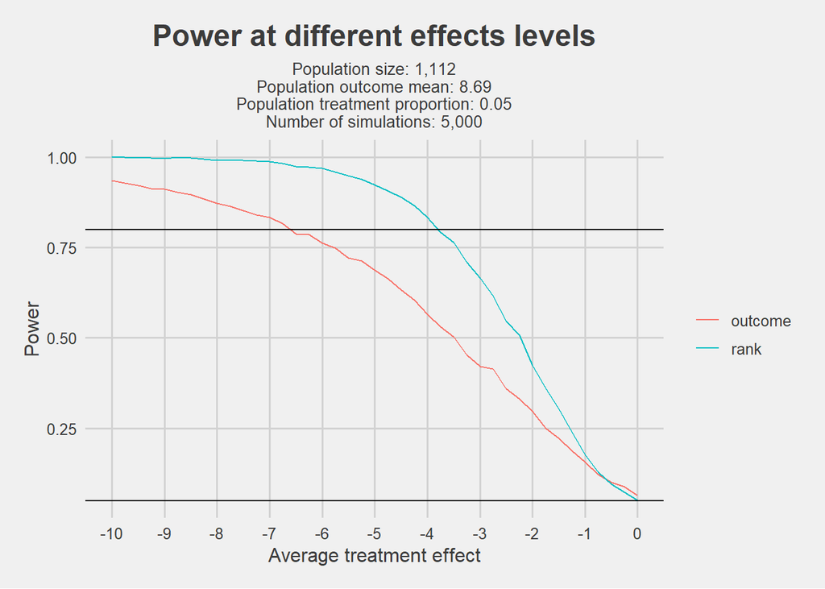

```r
powers %>%
    ggplot(aes(x = ate, y = power, color = regression)) +
    geom_line() +
    geom_hline(yintercept = c(.8,.05)) +
    ggthemes::theme_fivethirtyeight() +
    scale_x_continuous(limits = c(params$ate_min,params$ate_max),
        breaks = scales::pretty_breaks(n = 10)) +
    # scale_color_oes() +
    # scale_fill_oes() +
    labs(
        title = "Power at different effects levels",
        subtitle = glue::glue("Population size: {scales::comma(population_size_color_contrast_issues)}
            Population outcome mean: {scales::comma(population_mean_color_contrast_issues, accuracy = .01)}
            Population treatment proportion: {scales::comma(population_treatement_proportion, accuracy = .01)}
            Number of simulations: {scales::comma(params$simulations)}
            ")

            ) +
        xlab("Average treatment effect") +
        ylab("Power") +
        theme(
            axis.title = element_text(),
            legend.title = element_blank(),
            legend.position = "right",
            legend.direction = "vertical",
            plot.title = element_text(hjust = 0.5),
            plot.subtitle = element_text(hjust = 0.5,
                size = 10)
        )
```

```r
tbl <- powers %>%
    filter(power >= .8) %>%
    group_by(regression) %>%
    filter(power == min(power)) %>%
    ungroup() %>%
    dplyr::select(regression, power, ate) %>%
    mutate(regression = str_to_title(regression)) %>%
  rename_all(~str_to_title(.)) %>%
  rename("Minimum detectable effect" = Ate)

tbl
```

```
## # A tibble: 2 × 3
##   Regression Power `Minimum detectable effect`
##   <chr>      <dbl>                       <dbl>
## 1 Outcome    0.816                       -6.75
## 2 Rank       0.833                       -4
```

```r
tbl %>%
  flextable() %>%
  autofit()
```

| Regression | Power | Minimum detectable effect |
| --- | --- | --- |
| Outcome | 0.8162 | -6.75 |
| Rank | 0.8334 | -4.00 |